# R Markdown Document 1

Martin Conyon

2022-08-03

# This is a level 1 header

## R Markdown

### This is a level 3 header

Here is a word in **bold** and another word in **bold**.

Here is a word in *italics* and another word in *italics*.

When we compile our document, we are using the `rmarkdown` package.

When we compile we use `Rmarkdown`

Here are some example R commands:

```
2+2
mean(c(1,2,3,4,5))
```

### Non-numbered list

Here is an example of a non-numbered list:

- Breakfast
  - food
    - eggs
    - toast
    - bacon
  - drink
    - apple juice
- Lunch
  - taco
- Dinner
  - baked chicken
  - broccoli
  - rice

### Numbered list

Here is an example of a numbered list:

1. Breakfast
   1. food
      1. eggs
      2. toast
      3. bacon
   2. drink
      1. apple juice
2. Lunch
   1. taco
3. Dinner
   1. baked chicken
   2. broccoli
   3. rice

### Blockk quote

Here is an example of a blockquote:

> This is a block quote. This paragraph has two lines.
> 1. This is a list inside a block quote.
> 2. Second item.

### Block quote - with italics

Here is an example of a blockquote:

> *This is a block quote. This paragraph has two lines.*
> 1. This is a list inside a block quote.
> 2. Second item.

> *Like this?*

### Nested Blockquote

Here is an example of a nested blockquote:

> This is a block quote. This paragraph has two lines.

> > This text is nested

## Code Blockquote

Here is an example of code in a blockquote:

> ```
> 2+2
> mean(c(1,2,3,4,5))
> ```

## Insert Tables

```r
knitr::kable(head(cars))
```

| speed | dist |
| --- | --- |
| 4 | 2 |
| 4 | 10 |
| 7 | 4 |
| 7 | 22 |
| 8 | 16 |
| 9 | 10 |

## Quick regression

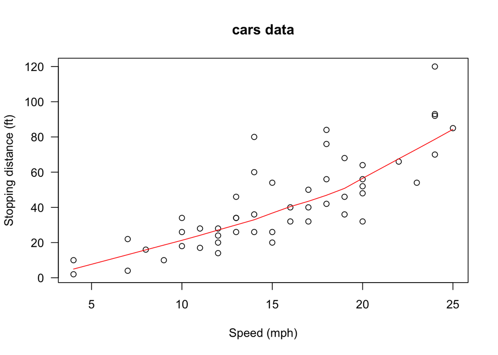

```r
require(stats); require(graphics)
plot(cars, xlab = "Speed (mph)", ylab = "Stopping distance (ft)",
     las = 1)
lines(lowess(cars$speed, cars$dist, f = 2/3, iter = 3), col = "red")
title(main = "cars data")
```

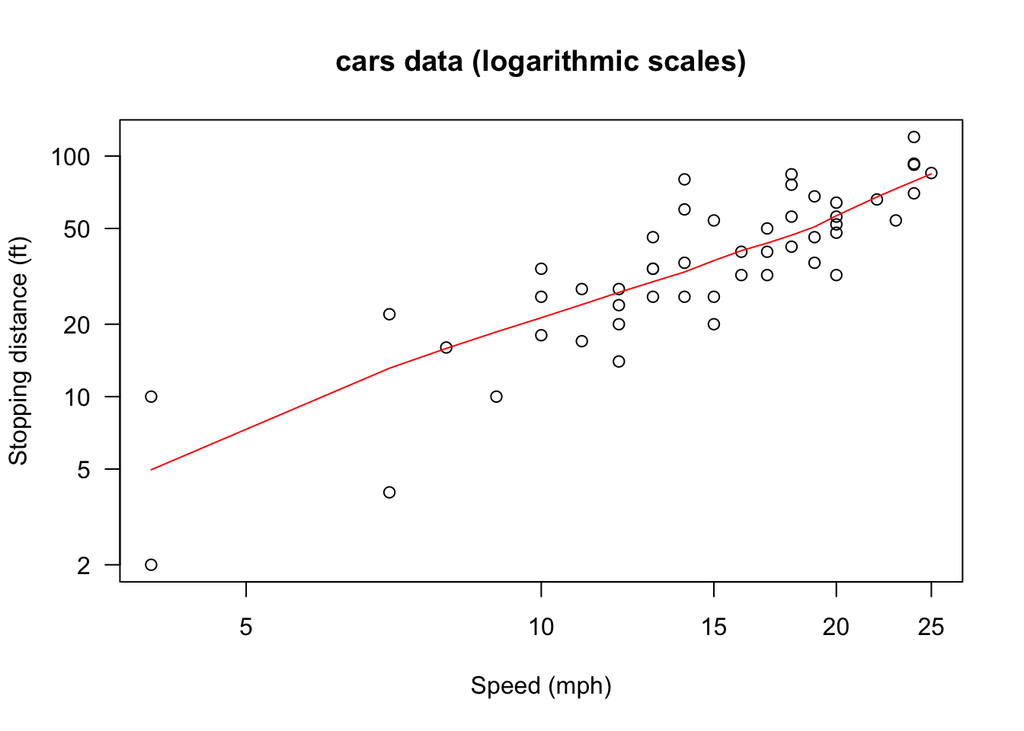

```r
plot(cars, xlab = "Speed (mph)", ylab = "Stopping distance (ft)",
     las = 1, log = "xy")
title(main = "cars data (logarithmic scales)")
lines(lowess(cars$speed, cars$dist, f = 2/3, iter = 3), col = "red")
```

```r
summary(fm1 <- lm(log(dist) ~ log(speed), data = cars))
```

```
##
## Call:
## lm(formula = log(dist) ~ log(speed), data = cars)
##
## Residuals:
##      Min       1Q   Median       3Q      Max
## -1.00215 -0.24578 -0.02898  0.20717  0.88289
##
## Coefficients:
##             Estimate Std. Error t value Pr(>|t|)
## (Intercept)  -0.7297     0.3758  -1.941   0.0581 .
## log(speed)    1.6024     0.1395  11.484 2.26e-15 ***
## ---
## Signif. codes:  0 '***' 0.001 '**' 0.01 '*' 0.05 '.' 0.1 ' ' 1
##
## Residual standard error: 0.4053 on 48 degrees of freedom
## Multiple R-squared:  0.7331, Adjusted R-squared:  0.7276
## F-statistic: 131.9 on 1 and 48 DF,  p-value: 2.259e-15
```

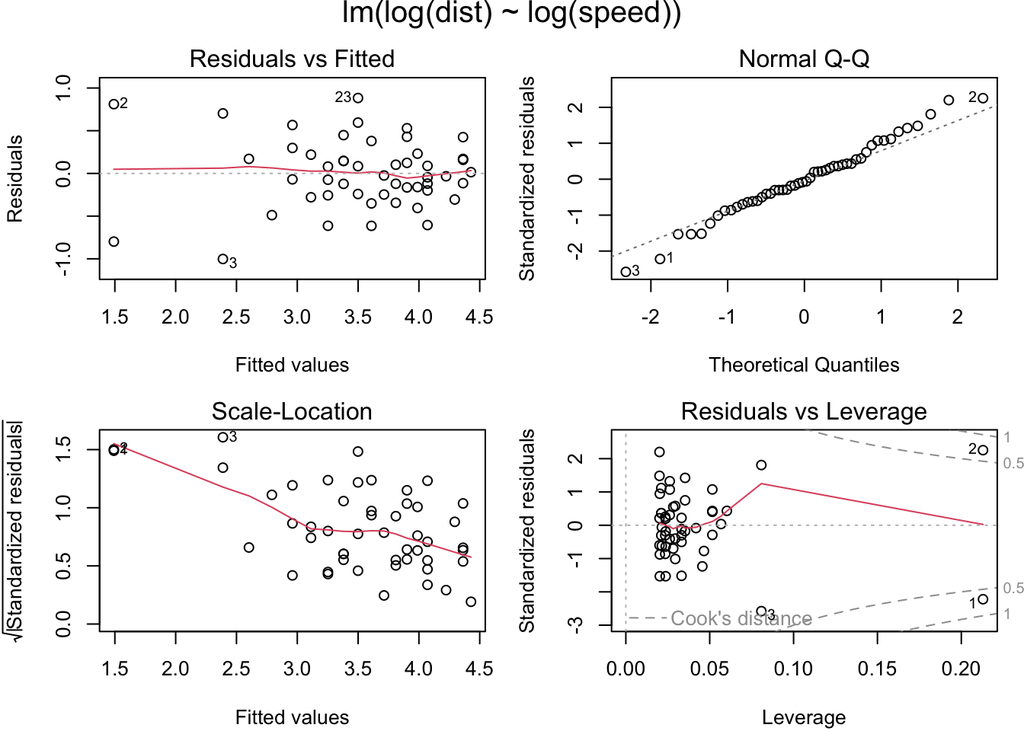

```r
opar <- par(mfrow = c(2, 2), oma = c(0, 0, 1.1, 0),
            mar = c(4.1, 4.1, 2.1, 1.1))
plot(fm1)
```

```r
par(opar)
```

## Back to Tables

```r
knitr::kable(head(cars), caption = "Top Six Rows of Data Set")
```

Top Six Rows of Data Set

| speed | dist |
| --- | --- |
| 4 | 2 |
| 4 | 10 |
| 7 | 4 |
| 7 | 22 |
| 8 | 16 |
| 9 | 10 |

## Insert Equation

$$Y=\beta_0 + \beta_1X$$

## Insert Images

Here is an image

[figure not shown]

sunstar

Here is the R logo

[figure not shown]

r logo

[video not shown]

sunstar